# session_03_exercises

## Linear Regression

In this exercise session we will see how to perform one- and multidimensional regression tasks on a given dataset. We will learn to use the python libraries **scipy.stats** as well as **statsmodels** to find regression parameters and their statistics.

Depending on the environment you are using, **statsmodels** can be installed (via terminal) by typing

- *pip3 install statsmodels*

```python
# Load all dependencies
import numpy as np
import matplotlib.pyplot as plt
import pandas as pd
import scipy.stats as stats
import statsmodels.formula.api as sm
from patsy.builtins import * # tools for code evaluated in formulas (like those of statsmodels)
%matplotlib inline
```

For the sake of learning the libraries functionality, let's create some easy data samples following a linear relation with gaussian scatter on top of it. Let us first take a look at **stats.linregress**.

```
slope:	 0.504
inter:	 2.004
r2 val:	 0.984
p  val:	 1.3593880270442175e-74
std:	 0.009
```

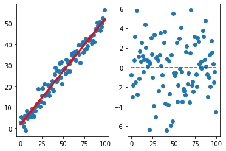

```python
# set up some sample data
x = np.arange(100)
y = 0.5 * x + 2.0 + np.random.normal(0, 3, x.shape)

# linear regression fit
s, inter, r_value, p_value, std_err = stats.linregress(x, y)
line = s * x + inter

print('slope:\t', round(s, 3))
print('inter:\t', round(inter, 3))
print('r2 val:\t', round(r_value, 3))
print('p  val:\t', p_value)
print('std:\t', round(std_err, 3))

# plotting and comparison
f, (ax0, ax1) = plt.subplots(1, 2)
ax0.scatter(x, y)
ax0.plot(x, line, lw=3, color='red')

# plot the residuals
ax1.scatter(x, line-y)
ax1.plot(x, np.zeros_like(x), 'g--')
```

Now let's do the same with the **statsmodels** package.

```python
# set up some sample data
x = np.arange(100)
y = 0.5 * x + 2.0 + np.random.normal(0, 3, x.shape)

df = pd.DataFrame({'x': x, 'y': y})

# linear regression fit
reg = sm.ols(formula='y ~ x', data=df).fit()
reg.summary()
#print(dir(reg))
```

OLS Regression Results

| Dep. Variable: | y | R-squared: | 0.957 |
| --- | --- | --- | --- |
| Model: | OLS | Adj. R-squared: | 0.957 |
| Method: | Least Squares | F-statistic: | 2200. |
| Date: | Thu, 11 Mar 2021 | Prob (F-statistic): | 6.06e-69 |
| Time: | 13:10:25 | Log-Likelihood: | -252.62 |
| No. Observations: | 100 | AIC: | 509.2 |
| Df Residuals: | 98 | BIC: | 514.4 |
| Df Model: | 1 |  |  |
| Covariance Type: | nonrobust |  |  |

|  | coef | std err | t | P>\|t\| | [0.025 | 0.975] |
| --- | --- | --- | --- | --- | --- | --- |
| Intercept | 1.9361 | 0.607 | 3.191 | 0.002 | 0.732 | 3.140 |
| x | 0.4966 | 0.011 | 46.899 | 0.000 | 0.476 | 0.518 |

| Omnibus: | 1.839 | Durbin-Watson: | 1.775 |
| --- | --- | --- | --- |
| Prob(Omnibus): | 0.399 | Jarque-Bera (JB): | 1.372 |
| Skew: | -0.031 | Prob(JB): | 0.504 |
| Kurtosis: | 2.430 | Cond. No. | 114. |

Notes:  
[1] Standard Errors assume that the covariance matrix of the errors is correctly specified.

Let's use the data provided in the data folder of this weeks exercise to practice linear regression (bird_data_vincze_etal_2015.csv).

```
slope:	 0.49662289116995206
inter:	 1.9361458418845667
r2 val:	 0.9573460943940644
```

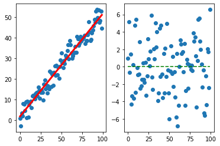

```python
# read out the fitting parameters
inter, s = reg.params
line = s * x + inter
print('slope:\t', s)
print('inter:\t', inter)
print('r2 val:\t', reg.rsquared)

# plotting and comparison
f, (ax0, ax1) = plt.subplots(1, 2)
ax0.scatter(x, y)
ax0.plot(x, line, lw=3, color='red')

# plot the residuals
ax1.scatter(x, line-y)
ax1.plot(x, np.zeros_like(x), 'g--')
```

### Exercise 1: Inverting the fitting procedure

The above algorithms fit the underlying data columns by means of the least-square method. What happens if instead of fitting **y~x** we fit **x~y**? Are the results the same? Why or why not? Show the comparison numerically (values of *s* and *inter*) and visually.

```
  param     y ~ x      x ~ y
0  iter  1.936146  23.974602
1     s  0.496623   0.959934
```

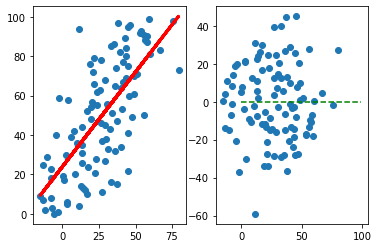

```python
# set up some sample data
x = np.arange(100)
y = 0.5 * x + 2.0 + np.random.normal(0, 15, x.shape)

df_rev = pd.DataFrame({"x" : x, "y" : y})

# perform the linear regression fits
reg_rev = sm.ols(formula = 'x ~ y', data = df_rev).fit()
reg_rev.summary()

inter_rev, s_rev = reg_rev.params

# difference numerically
print(pd.DataFrame({"param" : ["iter", "s"],
              "y ~ x" : [inter, s],
              "x ~ y" : [inter_rev, s_rev]}))


# show your results visually
line_rev = s_rev * y + inter_rev

fig, (ax0, ax1) = plt.subplots(1,2)
ax0.scatter(y, x)
ax0.plot(y, line_rev, lw=3, color='red')

ax1.scatter(y, line_rev-x)
ax1.plot(x, np.zeros_like(y), "g--")

## TODO: check the solution!!!
```

### Data transformations

Nature likes power laws...

Often columns in the provided data are in fact correlated but the linear fitting requires to transform one or even both columns, e.g. through the **log-transformation**.

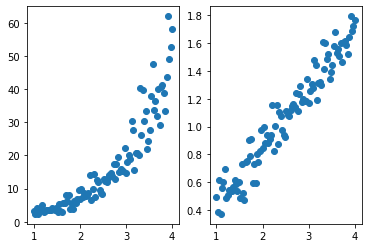

```python
# an example case
x = np.linspace(1, 4, 100)
y = np.exp(x + np.random.normal(0, .2, x.shape))

f, (ax0, ax1) = plt.subplots(1, 2)
ax0.scatter(x, y)
ax1.scatter(x, np.log10(y))
```

### Exercise 2: Combining transformations and linear regression

- Load the **bird_data_vincze_etal_2015.csv** dataset from the data folder as a pandas dataframe and examine the columns.
- Perform linear regression on the column pairs (you may want to transform your data accordingly before fitting).
  - (Wing area, Brain mass)
  - (Wing area, Body mass)
- *(optional)* Invert all fits as before. Are the results the same?

```
                   Species  Migration distance  Body mass  Brain mass  \
0       Accipiter gentilis               542.0     1100.0       7.674
1          Accipiter nisus              2938.1      260.0       3.081
2  Acrocephalus scirpaceus              3577.0       14.0       0.483
3      Aegithalos caudatus                26.1        7.5       0.456
4        Aegypius monachus               972.2     9000.0      24.808

   Size of cerebellum  Size of telencephalon  Size of optic lobe  \
0               1.088                  4.617               0.837
1               0.499                  1.593               0.440
2               0.066                  0.282               0.070
3               0.035                  0.283               0.059
4               2.812                 17.936               1.020

   Wing aspect ratio  Wing area
0              5.841      0.193
1              5.891      0.093
2              4.835      0.008
3              4.463      0.007
4                NaN        NaN
```

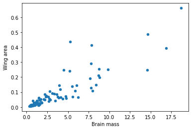

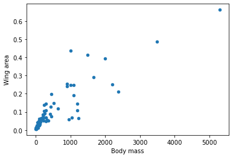

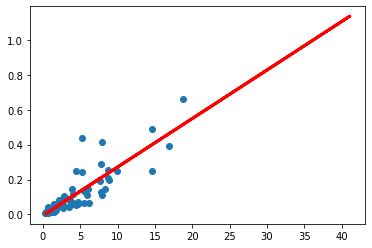

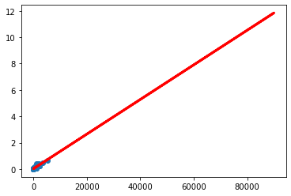

```python
# load the dataset and display some summary
bird_df = pd.read_csv("data/bird_data_vincze_etal_2015.csv")
print(bird_df.head())

# Perform the linear regression for (Wing area - Brain mass)
plt.figure()
bird_df.plot.scatter("Brain mass", "Wing area") # looks linear enough

reg = sm.ols(formula = "Q('Wing area') ~ Q('Brain mass')", data = bird_df).fit() # using Q tool from patsy.builtins API
reg.summary()

inter_brain, s_brain = reg.params
brain = bird_df.loc[:, "Brain mass"].values
wing = bird_df.loc[:, "Wing area"].values

line_brain = inter_brain + s_brain * brain

# Perform the linear regression for (Wing area - Body mass)
plt.figure()
bird_df.plot.scatter("Body mass", "Wing area") # looks linear enough

reg = sm.ols(formula = "Q('Wing area') ~ Q('Body mass')", data = bird_df).fit() # using Q tool from patsy.builtins API
reg.summary()

inter_body, s_body = reg.params
body = bird_df.loc[:, "Body mass"].values

line_body = inter_body + s_body * body

# Display your results visually

fig, ax0 = plt.subplots(1, 1)
ax0.scatter(brain, wing)
ax0.plot(brain, line_brain, lw=3, color='red')

fig, ax1 = plt.subplots(1, 1)
ax1.scatter(body, wing)
ax1.plot(body, line_body, lw=3, color='red')

## should do log-log fitting because of outliers
```

## Multiple linear regression

Let's now apply the same concepts to regress the best hyper-plane given three data columns. The following example performs a 2-dimensional regression (using least-squares method) to fit $z=a_{0} + a_{1}x + a_{2}y$

```python
# set up some sample data
x = np.random.uniform(-5, 5, 100)
y = np.random.uniform(-5, 5, 100)
z = 0.3*x + 0.2*y + np.random.normal(0, 0.25, x.shape)
print(x.shape, y.shape, z.shape)

# collect them in a pandas dataframe
df = pd.DataFrame({'x': x,
                   'y': y,
                   'z': z})

# linear regression fit
reg = sm.ols(formula='z ~ x + y', data=df).fit()
print(reg.summary())
```

```
(100,) (100,) (100,)
```

OLS Regression Results

| Dep. Variable: | z | R-squared: | 0.957 |
| --- | --- | --- | --- |
| Model: | OLS | Adj. R-squared: | 0.956 |
| Method: | Least Squares | F-statistic: | 1083. |
| Date: | Thu, 11 Mar 2021 | Prob (F-statistic): | 4.48e-67 |
| Time: | 14:02:22 | Log-Likelihood: | -8.0039 |
| No. Observations: | 100 | AIC: | 22.01 |
| Df Residuals: | 97 | BIC: | 29.82 |
| Df Model: | 2 |  |  |
| Covariance Type: | nonrobust |  |  |

|  | coef | std err | t | P>\|t\| | [0.025 | 0.975] |
| --- | --- | --- | --- | --- | --- | --- |
| Intercept | -0.0009 | 0.027 | -0.035 | 0.972 | -0.054 | 0.052 |
| x | 0.3076 | 0.009 | 35.599 | 0.000 | 0.290 | 0.325 |
| y | 0.2063 | 0.009 | 22.603 | 0.000 | 0.188 | 0.224 |

| Omnibus: | 1.069 | Durbin-Watson: | 1.900 |
| --- | --- | --- | --- |
| Prob(Omnibus): | 0.586 | Jarque-Bera (JB): | 1.062 |
| Skew: | -0.115 | Prob(JB): | 0.588 |
| Kurtosis: | 2.551 | Cond. No. | 3.37 |

Notes:  
[1] Standard Errors assume that the covariance matrix of the errors is correctly specified.

```
The fitting formula is: z = -0.001 + 0.308 x + 0.206 y
```

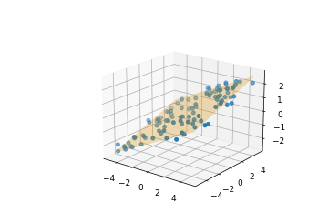

```python
from mpl_toolkits.mplot3d import Axes3D
%matplotlib notebook

a0, a1, a2 = reg.params
print('The fitting formula is: z = {0:} + {1:} x + {2:} y'.format(round(a0, 3),
                                                                  round(a1, 3),
                                                                  round(a2, 3)))

fig = plt.figure()
ax = fig.add_subplot(111, projection='3d')
ax.scatter(x, y, z)

# set up the surface plot
X = np.linspace(-5, 5, 100)
Y = np.linspace(-5, 5, 100)
XX, YY = np.meshgrid(X, Y)
ZZ = a0 + a1 * XX + a2 * YY
ax.plot_surface(XX, YY, ZZ, alpha=0.3, color='orange')
```

### Exercise 3: Multiple linear regression

- Load the _multi_regression.csv_ from the data folder and examine the dataset. Make a scatter plot of **(x,y,z)**.
- Applying the techniques from above, fit the three datacolumns using multidimensional linear regression.

```
   Unnamed: 0             x          y          z
0           0  79089.354518  -2.161552   8.754115
1           1   1217.243171  -0.852142   5.629499
2           2  41035.946100 -13.695592  11.071939
3           3     52.034894   1.087340   1.994319
4           4      5.122800   4.858077   0.055242
   Unnamed: 0         x          y          z
0           0  4.898118  -2.161552   8.754115
1           1  3.085377  -0.852142   5.629499
2           2  4.613164 -13.695592  11.071939
3           3  1.716295   1.087340   1.994319
4           4  0.709507   4.858077   0.055242
```

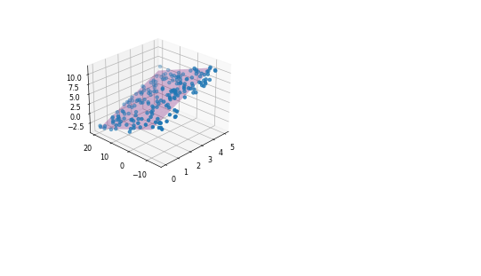

```
                            OLS Regression Results
==============================================================================
Dep. Variable:                      z   R-squared:                       0.979
Model:                            OLS   Adj. R-squared:                  0.979
Method:                 Least Squares   F-statistic:                     4567.
Date:                Thu, 11 Mar 2021   Prob (F-statistic):          9.28e-166
Time:                        14:34:43   Log-Likelihood:                -149.19
No. Observations:                 200   AIC:                             304.4
Df Residuals:                     197   BIC:                             314.3
Df Model:                           2
Covariance Type:            nonrobust
==============================================================================
                 coef    std err          t      P>|t|      [0.025      0.975]
------------------------------------------------------------------------------
Intercept     -0.0025      0.075     -0.033      0.974      -0.151       0.146
x              1.7043      0.025     69.157      0.000       1.656       1.753
y             -0.2003      0.004    -56.762      0.000      -0.207      -0.193
==============================================================================
Omnibus:                        5.316   Durbin-Watson:                   2.088
Prob(Omnibus):                  0.070   Jarque-Bera (JB):                4.980
Skew:                           0.326   Prob(JB):                       0.0829
Kurtosis:                       3.415   Cond. No.                         23.2
==============================================================================

Notes:
[1] Standard Errors assume that the covariance matrix of the errors is correctly specified.
the regression formula is: z = -0.00246 + 1.7 x + -0.2 y
```

```python
# load the data
multi = pd.read_csv("data/multi_regression.csv")
print(multi.head())
x = np.log10(multi.loc[:, "x"].values)
y = multi.loc[:, "y"].values
z = multi.loc[:, "z"].values
multi.loc[:, "x"] = np.log10(multi.loc[:, "x"])
print(multi.head())

# examine the data by scatter plotting it directly
fig = plt.figure()
ax = fig.add_subplot(111, projection='3d')
ax.scatter(x, y, z)

# find a suitable fit for the data and perform multiple linear regression
reg = sm.ols(formula='z ~ x + y', data=multi).fit()
print(reg.summary())

a0, a1, a2 = reg.params
print("the regression formula is: z = {0:.3} + {1:.3} x + {2:.3} y".format(a0, a1, a2))

# visualize your results
X = np.linspace(0, 5, 100)
Y = np.linspace(-10, 20, 100)
xx, yy = np.meshgrid(X, Y)
zz = a0 + a1*xx + a2*yy
ax.plot_surface(xx, yy, zz, color = 'purple', alpha = .3)
```